# Greenblotched Rockfish

*Sebastes rosenblatti*

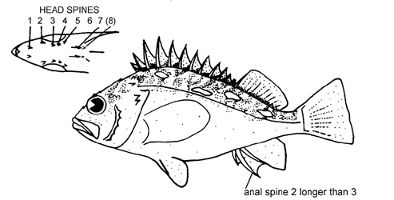

**Body color:** Faded pink w/ vague green streaks and small blotches on back; 3 to 5 whitish blotches on back; fins yellow-pink.

**Peritoneum color:** dark or light **Shape between eyes:** concave

**Counts:** D:XIII-XIV,11-13, Ar:5-6, P1:16-18, GR:28-34, LLp:34-42, LLs:43-54, V:26

**Occurence:** Central California - Baja California

**Depth:** 396 meters **Size:** 56 cm **Species code:** 30611

**Similar species:**

- *Pink rockfish* - pectoral rays typically 18 (typically 17 in Greenblotched RF); gillrakers typically 26-30 (30-34 in Greenblotched RF); spines on lower edge of operculum typically 1-2 (absent in Greenblotched RF); upper gillrakers rudimentary (not rudimentary in Greenblotched RF)
- *Greenspotted rockfish* - body w/ round green spots; scales on lower jaw few or absent (lower jaw scaled in Greenblotched RF)
- *Rosethorn rockfish* - pectoral rays typically 16 (17 in Greenblotched RF)
- *Freckled rockfish* - prominent knobs bordering notch in upper jaw (absent in Greenblotched RF); back w/ dense freckling; gillrakers 34-39 (30-34 in Greenblotched RF)
- *Rosy rockfish* - body red mottled w/ purple, w/out green spots and streaks; scales on lower jaw few or absent (scaled in Greenblotched RF)
- *Pinkrose rockfish* - body uniform red; scales on lower jaw few or absent (scaled in Greenblotched RF)

Back to Group

**Corrections:** If you see mistakes or want to suggest changes, please create an [issue](https://github.com/zoyafuso-NOAA/RACE_Survey_App/issues) on the source repository or

*reach out to Liz Dawson (Liz.Dawson AT noaa.gov).*